# Assignment 2 Task 1: Wilamette Falls Fish Passage

Lory Salazar, Marie Bouffard, Ruiheng Jin

2/4/2021

## Overview

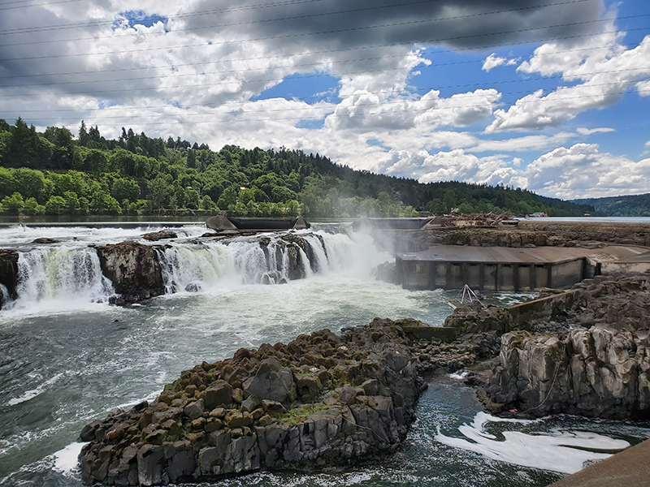

A view of Portland General Electric’s hydropower project at Willamette Falls. Source: Portland General Electric

Summary:

This report provides an overview of adult salmon passage at the Willamette Falls fish ladder, for three species of fish (Coho, Jack-Coho, and Steelhead) observed at Willamette River in Oregon from 2001 to 2010 (Columbia River DART). The first plot, a static time series graph explores overall pasage counts by species. Second, a seasonplot examines how species passage counts vary by month for each year from 2001 to 2010. The final plot shows annual counts by species in order to look specifically at trends in annual abundance of the three species over the time period.

Source: US Army Corps of Engineers, Portland District

Data citation:

Columbia River DART, Columbia Basin Research, University of Washington. (2021). Adult Passage Daily Counts. Available from http://www.cbr.washington.edu/dart/query/adult_daily

```r
# Reading in the data
fish <- read.csv(here("data", "willamette_fish_passage.csv")) %>%
  clean_names()

# Create a subset of just the three species of interest, using pivot_longer to put them in one singular column
fish_sub <- fish %>%
  select(date, coho, jack_coho, steelhead) %>%
  mutate(date = lubridate::mdy(date)) %>%
  mutate(year = year(date)) %>%
  pivot_longer(cols = coho:steelhead,
               names_to = "species",
               values_to = "count")

# Create a tsibble for each species (coho, jack_coho, steelhead)
# coho
coho_ts <- fish_sub %>%
  filter(species == "coho") %>%
  select(date, count) %>%
  mutate(replace(., is.na(.), 0)) %>%
  as_tsibble(key = NULL, index = date)

# jack_coho
jack_coho_ts <- fish_sub %>%
  filter(species == "jack_coho") %>%
  mutate(replace(., is.na(.), 0)) %>%
  as_tsibble(key = NULL, index = date)

# steelhead
steelhead_ts <- fish_sub %>%
  filter(species == "steelhead") %>%
  mutate(replace(., is.na(.), 0)) %>%
  as_tsibble(key = NULL, index = date)
```

### Original time series

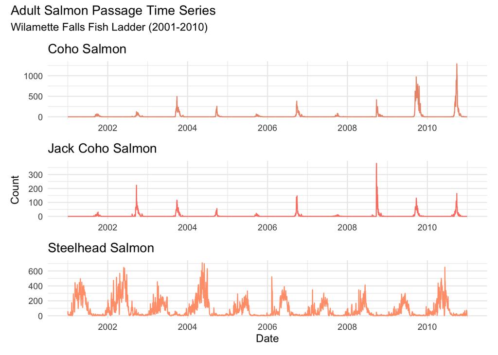

```r
# Create static graph of adult passage for coho, jack coho, and steelhead salmon

# Coho
coho_static <- ggplot(data = coho_ts, aes(x = date, y = count)) +
  geom_line(color = "darksalmon") +
  labs(title = "Coho Salmon") +
  theme_minimal() +
  theme(axis.title.x = element_blank(),
        axis.title.y = element_blank())

# Jack Coho
jack_static <- ggplot(data = jack_coho_ts, aes(x = date, y = count)) +
  geom_line(color = "salmon") +
  labs(title = "Jack Coho Salmon",
       y = "Count") +
  theme_minimal() +
  theme(axis.title.x = element_blank())

# Steelhead
steelhead_static <- ggplot(data = steelhead_ts, aes(x = date, y = count)) +
  geom_line(color = "lightsalmon") +
  labs(title = "Steelhead Salmon",
       x = "Date") +
  theme_minimal() +
  theme(axis.title.y = element_blank())

# Patchwork to put pannels together
tab_1_patchwork <- (coho_static/jack_static/steelhead_static)

tab_1_patchwork + plot_annotation(
  title = "Adult Salmon Passage Time Series",
  subtitle = "Wilamette Falls Fish Ladder (2001-2010)",
)
```

**Figure 1.** Time series plot of adult passage counts for three salmon species, coho, jack coho, and steelhead at the Wilamette Falls fish ladder on the Willamette River in Oregon.

#### Summary

- Coho salmon passage appears to be seasonal, with strong peaks occurring at regular intervals in each year, with peaks seeming to trend upward.
- Jack coho salmon also appear to have strong seasonal peaks, at similar times in the year as coho salmon. From this plot, there does not appear to be a strong trend in changes in counts.
- Steelhead salmon also had seasonal peaks, though there were more fluctuations consistently between large peaks. From this plot, there is no clear discernible trend.

### Seasonplots

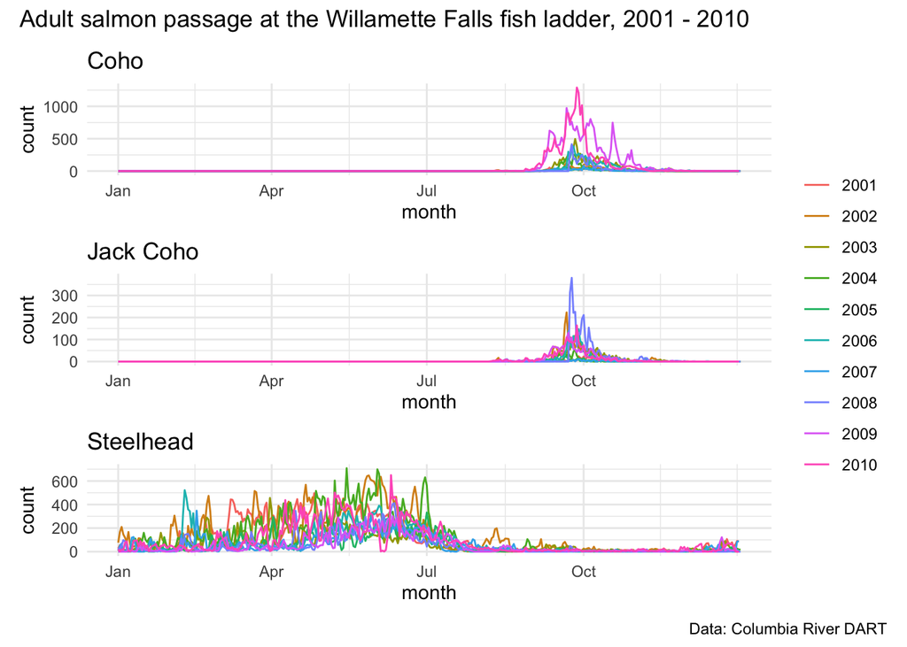

```r
# Creating a seasonplot for each species

coho_season <- coho_ts %>%
  gg_season(y = count) +
  theme_minimal() +
  labs(title = "Coho",
       x = "month")

jack_coho_season <- jack_coho_ts %>%
  gg_season(y = count) +
  theme_minimal()+
  labs(title = "Jack Coho",
       x = "month")


steelhead_season <- steelhead_ts %>%
  gg_season(y = count) +
  theme_minimal()+
  labs(title = "Steelhead",
       x = "month")


patchwork <- (coho_season / jack_coho_season / steelhead_season) +
  plot_layout(guides = 'collect')

patchwork + plot_annotation(
  title = "Adult salmon passage at the Willamette Falls fish ladder, 2001 - 2010",
  caption = "Data: Columbia River DART"
)
```

**Figure 2.** Seasonal plot for salmon passage counts at the Willamette Falls fish ladder in Oregon. Passage counts of 3 species (Coho, Jack-Coho, and Steelhead) were measured from 2001-2010. Data: Columbia River DART.

### Annual counts

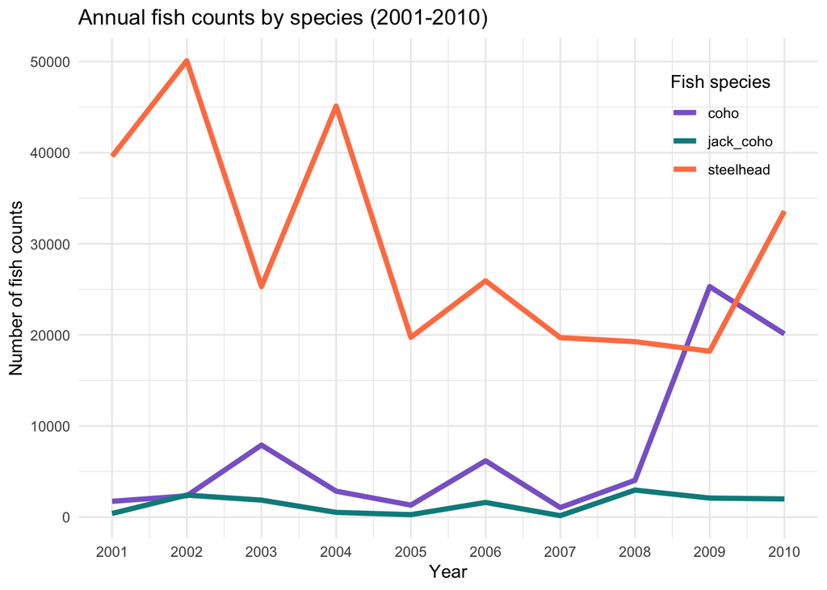

```r
# Group by year and count for each species
spp_date <- fish_sub %>%
  group_by(year) %>%
  count(species, wt = count)

# Creating a plot to visualize annual counts of the three species

ggplot(data = spp_date, aes(x = year, y = n)) +
  geom_line(size = 1.5, aes(color = species)) +
    scale_color_manual(values = c("mediumpurple3","cyan4","coral"),
                     name = "Fish species") +
  labs(title = "Annual fish counts by species (2001-2010)",
       x = "Year", y = "Number of fish counts") +
    scale_x_continuous(breaks = c(2001:2010)) +
  theme_minimal() +
  theme(legend.position = c(0.87, 0.82))
```

**Figure 3.** Coho, Jack-Coho, and Steelhead fish counts, measured by time (years) from 2001-2010. Purple (Coho), teal (Jack-Coho) and coral (Steelhead) lines indicate total annual counts per species. Data: Columbia River DART.